# Cargas cruzadas y correlaciones entre factores específicos en CFA y ESEM Bifactor

Un estudio de simulación con estructuras bifactor complejas y rotación extended target

Brian N. Peña-Calero

Universidad Complutense de Madrid

18 abril, 2025

# Introducción

## Planteamiento del Problema

Los modelos bifactor tradicionales permiten evaluar simultáneamente un factor general y múltiples factores específicos, ofreciendo índices (e.g., ω_H, ECV, PUC) que clarifican la distribución de la varianza común en una estructura factorial compleja (Rodriguez, Reise, y Haviland 2016).

Sin embargo, en escenarios reales, podría existir más de un factor general o una estructura donde múltiples factores generales conviven junto con factores específicos, configuraciones abordadas bajo enfoques como los modelos de múltiples factores generales (Multiple General Factors - MGF; (Jiménez et al. 2023)).

## Planteamiento del Problema

En estos contextos, utilizar enfoques estrictamente confirmatorios (CFA bifactor) suele imponer restricciones poco realistas, como la ausencia completa de cargas cruzadas, generando estimaciones potencialmente sesgadas o problemas de ajuste del modelo.

La Exploratory Structural Equation Modeling (ESEM) con rotación extended target (García-Garzón 2020; Howard et al. 2018) podría solucionar estas limitaciones, permitiendo modelar cargas cruzadas menores y expectativas teóricas flexibles sobre las correlaciones factoriales entre múltiples factores generales.

## Preguntas de Investigación

1. ¿Qué efectos tiene omitir un factor general (FG) cuando la estructura simulada contiene dos?
2. ¿Cuál es el impacto de permitir correlaciones entre factores específicos (FEs) cuando en realidad son ortogonales, y viceversa?
3. ¿Qué sucede cuando el modelo CFA/ESEM no refleja correctamente la correlación real entre los FGs?
4. ¿En qué medida las cargas cruzadas triviales, menores o moderadas afectan el ajuste y recuperación de parámetros?

## Preguntas de Investigación

5. ¿Pueden los modelos ESEM bifactor con rotación extended target inducir cargas cruzadas cuando estas no existen?
6. ¿Puede el modelo CFA bifactor recuperar correctamente la estructura cuando las cargas cruzadas (en FE o FG) son inexistentes o triviales?
7. ¿Qué diferencias existen en la precisión de recuperación de parámetros (cargas, correlaciones, convergencia) entre modelos CFA y ESEM bifactor bajo distintas condiciones simuladas?
8. ¿Qué diferencias en requisitos de tamaño muestral se presentan entre modelos CFA y ESEM bifactor?

## Hipótesis

- H1: Omitir un FG en la especificación del modelo producirá mal ajuste y sesgo en estimaciones de correlaciones entre FEs.
- H2: Modelar correlaciones entre FEs cuando no existen tenderá a generar correlaciones espurias, especialmente cuando un FG ha sido omitido.
- H3: La omisión de correlaciones reales entre FEs generará mal ajuste y sesgo en cargas.
- H4: Las cargas cruzadas reales (menores o moderadas) serán mejor recuperadas por ESEM bifactor con extended target que por CFA bifactor.

## Hipótesis

- H5: ESEM bifactor con extended target tenderá a generar cargas cruzadas espurias cuando estas no existen, aunque en menor magnitud si se especifica correctamente la estructura general.
- H6: CFA bifactor funcionará correctamente cuando las cargas cruzadas (en FE o FG) sean nulas o triviales, pero fallará cuando estas sean relevantes.
- H7: La correlación entre FGs influirá en la aparición de correlaciones espurias entre FEs cuando el modelo esté incorrectamente especificado.
- H8: ESEM bifactor con extended target requerirá tamaños muestrales ligeramente mayores para convergencia estable y recuperación precisa.

## Objetivos Generales

Evaluar la utilidad y precisión de los modelos ESEM bifactor con rotación extended target frente a modelos CFA bifactor tradicionales en contextos simulados con múltiples factores generales, factores específicos correlacionados o no, y distintos escenarios de cargas cruzadas.

## Objetivos Específicos

1. Comparar el ajuste global y la recuperación de parámetros entre modelos CFA y ESEM bifactor en estructuras con 2 FGs.
2. Evaluar el impacto de omitir un FG sobre las correlaciones estimadas entre FEs.
3. Determinar si modelar correlaciones entre FEs mejora el ajuste o genera sesgos cuando estas no existen en la población.
4. Explorar la aparición de cargas cruzadas espurias en modelos ESEM bifactor bajo estructuras simuladas sin cargas cruzadas reales.

## Objetivos Específicos

5. Evaluar si CFA bifactor puede recuperar correctamente la estructura en contextos sin cargas cruzadas o con cargas fantasmas (triviales).
6. Analizar el efecto del tamaño muestral sobre convergencia, ajuste y precisión de estimaciones.
7. Estimar el sesgo relativo en cargas, correlaciones y convergencia según modelo y condición simulada.

# Metodología

## Diseño de Simulación

| Factor | Niveles |
| --- | --- |
| Correlación entre FGs | .20, .50, .80 |
| Correlación entre FEs | 0.00 (ortogonales), 0.30 (correlacionados) |
| Cargas cruzadas (FE) | “none”, “phantom” (~0 ± 0.05), “0.15”, “0.25”, “0.40” |
| % de ítems con cargas cruzadas | “0”, “20%”, “40%” |
| Ruta de cargas cruzadas (FE) | “no aplica”, “sameFG”, “diffFG” |
| Cargas cruzadas debidas al FG | “none”, “phantom” (~0 ± 0.05) |

## Diseño de Simulación

| Factor | Niveles |
| --- | --- |
| Tamaño muestral | 200, 500, 800 |
| Estructura simulada | 2 FGs, 6 FEs (3 por FG), 5 ítems por FE |
| Cargas principales | FG: 0.60–0.80; FE: 0.30 ± 0.05 |

→ **Total: 252 combinaciones de simulación únicas (rep = 500)**

- Cuando `crossload_mag = "none"`, el `% de ítems` es `"0"`, `crossload_route = "no aplica"` y `crossload_FG = "none"`.
- Cuando `crossload_mag = "phantom"`, todas las cargas cruzadas (FE y FG) son ~0 (±0.05).
- Los otros casos de `crossload_mag`, un porcentaje (20% o 40%) de los ítems presentará dichas cargas cruzadas, mientras que el resto tendrá cargas `phantom`.

## Modelos a estimar

- CFA bifactor:
  1. 1 FG con FEs ortogonales (1FG-FE⊥)
  2. 1 FG con FEs correlacionados (1FG-FE↔︎)
  3. 2 FGs con FEs ortogonales (2FG-FE⊥)
  4. 2 FGs con FEs correlacionados (2FG-FE↔︎)
- ESEM bifactor extended target:
  5. 1 FG con FEs ortogonales (1FG-FE⊥)
  6. 1 FG con FEs correlacionados (1FG-FE↔︎)
  7. 2 FGs con FEs ortogonales (2FG-FE⊥)
  8. 2 FGs con FEs correlacionados (2FG-FE↔︎)

## Estimadores

Cada modelo se ajustará dos veces:

1. **ML** (máxima verosimilitud clásica)
2. **MLR** (máxima verosimilitud robusta Satorra–Bentler)

**Nota**

Esto permitirá comprobar la robustez de los resultados ante pequeñas desviaciones de normalidad que podrían ser introducidas al especificar las múltiples condiciones de simulación.

## Ejemplo de modelos:

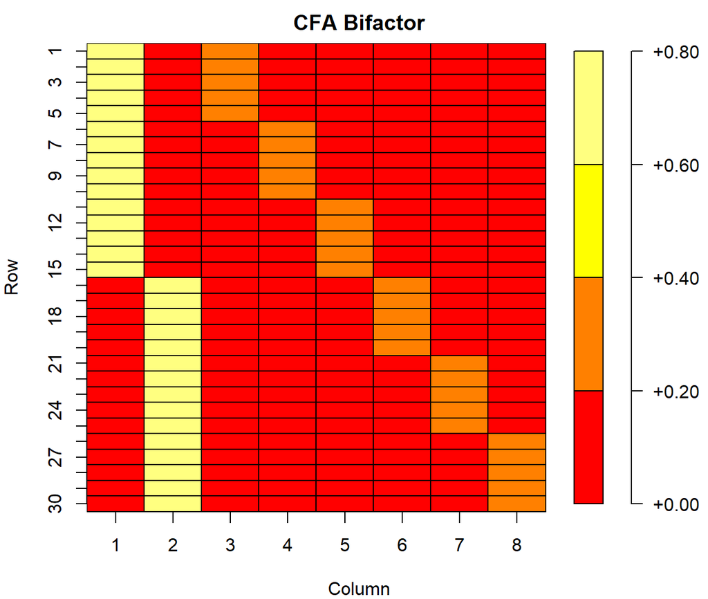

```r
par(mar = c(4, 4, 2, 3.5))
plot(bifactor_cfa_matrix, main = "CFA Bifactor")
```

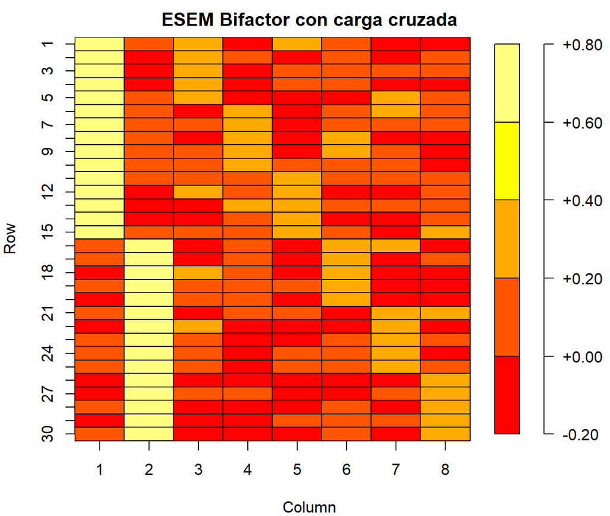

```r
par(mar = c(4, 4, 2, 3.5))
plot(esem_matrix, main = "ESEM Bifactor con carga cruzada")
```

## Plan de Análisis

1. **Ajuste global del modelo**: CFI, TLI, RMSEA, SRMR, USRMR
2. **Convergencia**: porcentaje de soluciones convergentes por condición y modelo
3. **Precisión de los parámetros**
   - Sesgo y RMSE de cargas principales y cruzadas
   - **MCSE** de cada estadístico (error Monte‑Carlo)
     $$\text{MCSE}(\hat{\theta}) = \frac{SD(\hat{\theta})}{\sqrt{R}}$$
   - **Bias de EE**: $\overline{SE} - SD(\hat \theta)$ relativo a $SD(\hat \theta)$
   - **Cobertura 95 %** de los IC para $\lambda$ y $\rho$

## Plan de Análisis

4. **Detección de efectos espurios**
   - *Cargas estimadas más allá de lo que debería*:
     - Si $\lambda_{pop}=0$ → espuria si $|\hat \lambda| ≥ .10$ (.15 en análisis de sensibilidad)
     - Si $\lambda_{pop} \approx 0$ (phantom) → espuria si $|\hat \lambda - \lambda_{pop}| ≥ .10$.
   - *Correlaciones*: criterio análogo para $\rho_{pop}=0$
5. **Comparación de modelos**:
   - ¿Cuál ofrece mejor ajuste y menor sesgo según cada estructura?
   - ¿Cuál es más robusto frente a especificación incorrecta?
6. **Evaluación según tamaño muestral**:
   - Comparar convergencia, ajuste y precisión entre N = 200, 500 y 800.

# Sobre la Simulación

## Procedimientos con software

Para la ejecución de este estudio se utilizó el paquete [`SimDesign`](https://CRAN.R-project.org/package=SimDesign) de R, el cual permite construir estudios de simulación siguiendo principios robustos de diseño experimental:

1. **`createDesign()`**: genera la matriz de condiciones del estudio.
2. **`Generate()`**: simula los datos en base a cada condición.
3. **`Analyse()`**: ejecuta los análisis especificados.
4. **`Summarise()`**: resume resultados por condición.
5. **`runSimulation()`**: integra todo el procedimiento con múltiples replicaciones.

[figure not shown]

## Gestión de scripts

El proyecto tendrá una estructura modular para la adecuada gestión de la simulación:

```
/simulacion-esem-bifactor/
│
├── 01-design.R            # Definición del diseño con createDesign()
├── 02-generate.R          # Función Generate()
├── 03-analyse.R           # Función Analyse()
├── 04-summarise.R         # Función Summarise()
├── 05-runSimulation.R     # Lógica principal que une todo y lanza SimDesign
│
├── /helpers/              # Funciones auxiliares (ej. crear matrices lambda, etc.)
│   └── simulate_structure.R
│
└── /outputs/              # Carpeta para guardar resultados
```

## Primero: createDesign()

```r
library(SimDesign)

Design <- createDesign(
  corr_FG = c(0.20, 0.50, 0.80),
  corr_FE = c(0.00, 0.30),
  crossload_mag = c("none", "phantom", "0.15", "0.25", "0.40"),
  crossload_perc = c("0", "0.20", "0.40"),
  crossload_route = c("no_aplica", "sameFG", "diffFG"),
  crossload_FG = c("none", "phantom"),
  sample_size = c(200, 500, 800),

  subset = !(
    # crossload_mag == "none" → todo debe ser explícitamente "none", "0", "no_aplica"
    (crossload_mag == "none" &
       (crossload_perc != "0" | crossload_route != "no_aplica" | crossload_FG != "none")) |

      # crossload_mag == "phantom" → también es una forma pura
      (crossload_mag == "phantom" &
         (crossload_perc != "0" | crossload_route != "no_aplica" | crossload_FG != "phantom")) |

      # Si hay cargas cruzadas reales (magnitudes definidas)
      (crossload_mag %in% c("0.15", "0.25", "0.40") &
         (crossload_perc == "0" | crossload_route == "no_aplica" | crossload_FG != "phantom"))
  )
)
```

## Primero: createDesign()

```r
Design
```

```
# A tibble: 252 × 7
   corr_FG corr_FE crossload_mag crossload_perc crossload_route crossload_FG
     <dbl>   <dbl> <chr>         <chr>          <chr>           <chr>
 1     0.2     0   none          0              no_aplica       none
 2     0.5     0   none          0              no_aplica       none
 3     0.8     0   none          0              no_aplica       none
 4     0.2     0.3 none          0              no_aplica       none
 5     0.5     0.3 none          0              no_aplica       none
 6     0.8     0.3 none          0              no_aplica       none
 7     0.2     0   phantom       0              no_aplica       phantom
 8     0.5     0   phantom       0              no_aplica       phantom
 9     0.8     0   phantom       0              no_aplica       phantom
10     0.2     0.3 phantom       0              no_aplica       phantom
# ℹ 242 more rows
# ℹ 1 more variable: sample_size <dbl>
```

## Referencias

García-Garzón, Eduardo. 2020. «Advances in Bi-factor Exploratory Modelling». Tesis doctoral, Madrid, España. https://repositorio.uam.es/.

Howard, Joshua L., Marylène Gagné, Alexandre J. S. Morin, y Jacques Forest. 2018. «Using Bifactor Exploratory Structural Equation Modeling to Test for a Continuum Structure of Motivation». *Journal of Management* 44 (7): 2638-64. https://doi.org/10.1177/0149206316645653.

Jiménez, Marcos, Francisco J. Abad, Eduardo Garcia-Garzon, Hudson Golino, Alexander P. Christensen, y Luis Eduardo Garrido. 2023. «Dimensionality Assessment in Bifactor Structures with Multiple General Factors: A Network Psychometrics Approach.» *Psychological Methods*, julio. https://doi.org/10.1037/met0000590.

Rodriguez, Anthony, Steven P. Reise, y Mark G. Haviland. 2016. «Applying Bifactor Statistical Indices in the Evaluation of Psychological Measures». *Journal of Personality Assessment* 98 (3): 223-37. https://doi.org/10.1080/00223891.2015.1089249.